# hw#4.data624

Sang Yoon (Andy) Hwang

September 22, 2019

# 7.8 Exercises

# 7.8.5 Data set books contains the daily sales of paperback and hardcover books at the same store. The task is to forecast the next four days’ sales for paperback and hardcover books.

# a. Plot the series and discuss the main features of the data.

From summary statistics, we know that Hardcover books are generally selling more overall - both mean and median are higher.

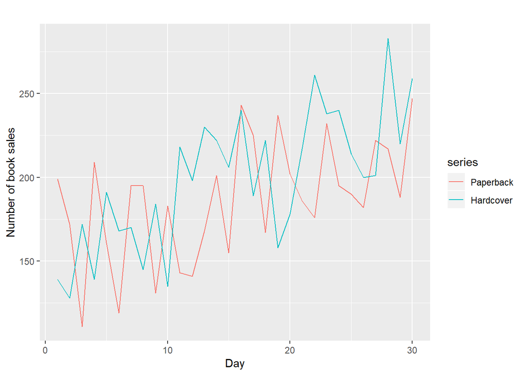

```r
# Daily pattern - general series
autoplot(books) +
  ylab("Number of book sales") + xlab("Day")
```

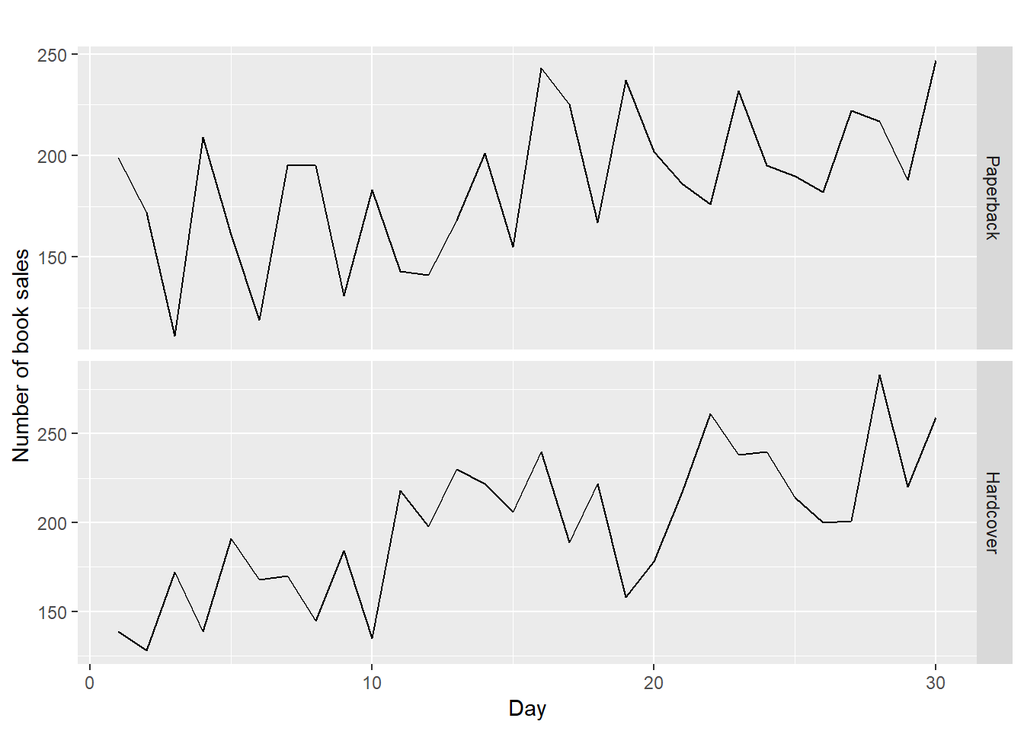

```r
# Daily pattern - sub series
autoplot(books, facets=TRUE) +
  ylab("Number of book sales") + xlab("Day")
```

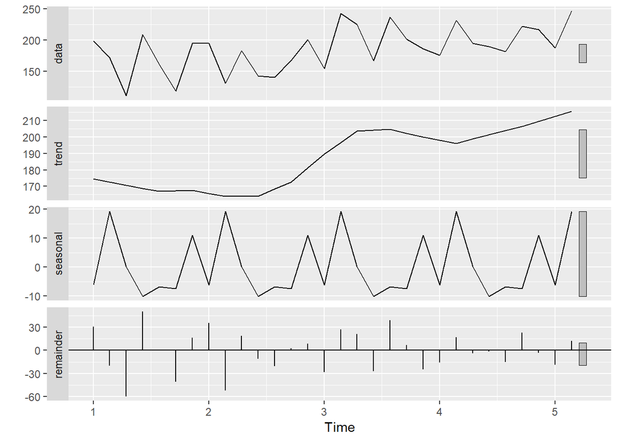

```r
# Weekly pattern
ts(books[, 'Paperback'], frequency = 7) %>%
  stl(s.window = 'periodic', robust = TRUE) %>%
  autoplot()
```

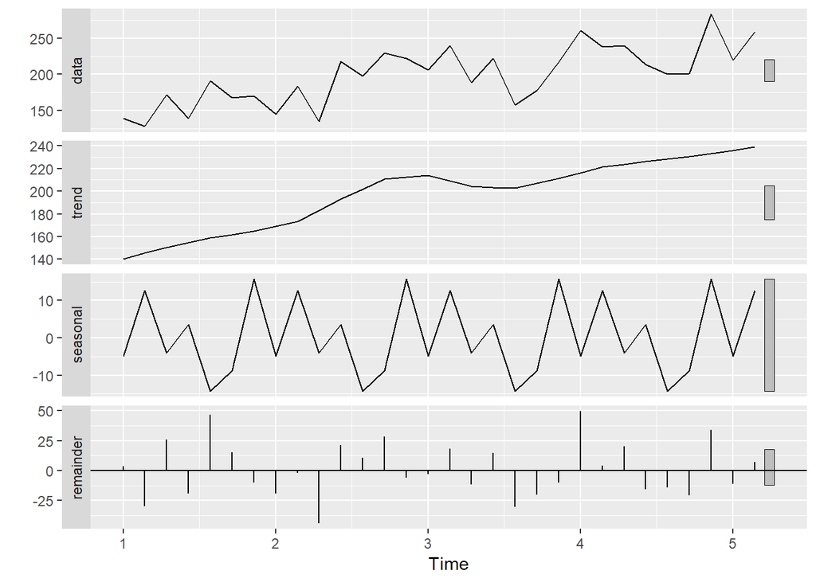

```r
ts(books[, 'Hardcover'], frequency = 7) %>%
  stl(s.window = 'periodic', robust = TRUE) %>%
  autoplot()
```

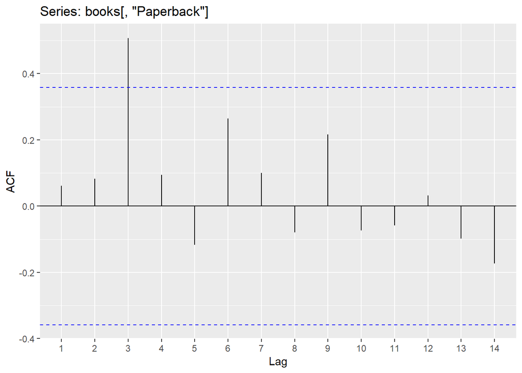

```r
#gglagplot(ts(books[, 'Paperback'], frequency = 7))
#gglagplot(ts(books[, 'Hardcover'], frequency = 7))

# Autocorrelation for each book
ggAcf(books[, 'Paperback'])
```

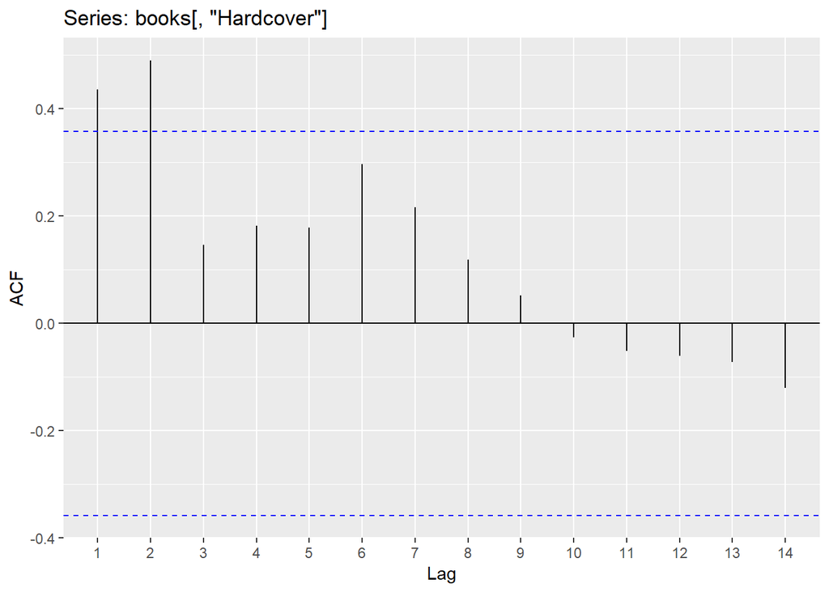

```r
ggAcf(books[, 'Hardcover'])
```

```r
# summary statistics
summary(books)
```

```
##    Paperback       Hardcover
##  Min.   :111.0   Min.   :128.0
##  1st Qu.:167.2   1st Qu.:170.5
##  Median :189.0   Median :200.5
##  Mean   :186.4   Mean   :198.8
##  3rd Qu.:207.2   3rd Qu.:222.0
##  Max.   :247.0   Max.   :283.0
```

# b. Use the ses() function to forecast each series, and plot the forecasts.

As we can see, since SES is suitable for data with no clear trend and seasonal pattern, we have flat forecast.

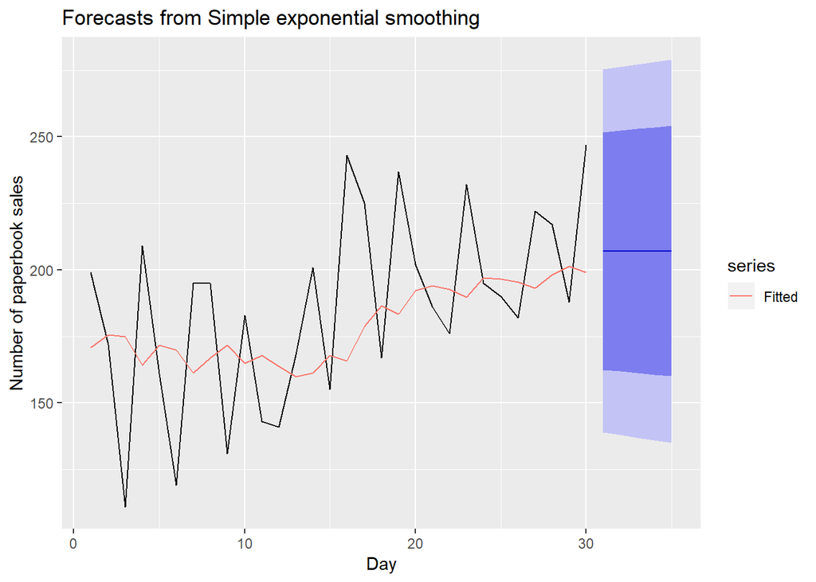

```r
# Estimate parameters
fc_paper <- ses(books[, 'Paperback'], h=5)
fc_hard <- ses(books[, 'Hardcover'], h=5)

autoplot(fc_paper) +
  autolayer(fitted(fc_paper), series="Fitted") +
  ylab("Number of paperbook sales") + xlab("Day")
```

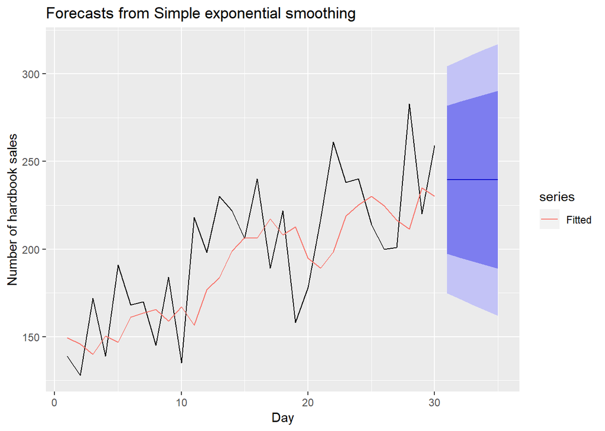

```r
autoplot(fc_hard) +
  autolayer(fitted(fc_hard), series="Fitted") +
  ylab("Number of hardbook sales") + xlab("Day")
```

# c. Compute the RMSE values for the training data in each case.

RMSE for Paperbook (training set) is higher than the one for Hardbook (training set).

```r
#accuracy(fitted(fc_paper), books[, 'Paperback'])
accuracy(fc_paper)
```

```
##                    ME     RMSE     MAE       MPE     MAPE      MASE
## Training set 7.175981 33.63769 27.8431 0.4736071 15.57784 0.7021303
##                    ACF1
## Training set -0.2117522
```

```r
accuracy(fc_hard)
```

```
##                    ME     RMSE      MAE      MPE     MAPE      MASE
## Training set 9.166735 31.93101 26.77319 2.636189 13.39487 0.7987887
##                    ACF1
## Training set -0.1417763
```

# 7.8.6

# a. Now apply Holt’s linear method to the paperback and hardback series and compute four-day forecasts in each case.

As we expected, since Holt’s linear method is linear, we see the linear trend forecasting line.

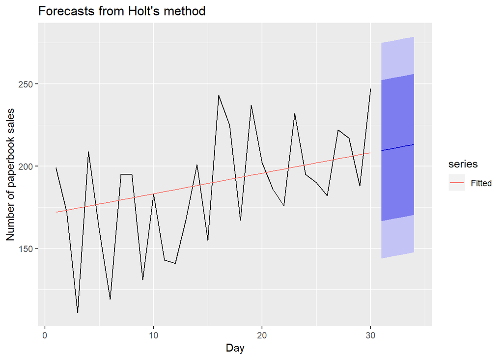

```r
fc_paper_hl <- holt(books[, 'Paperback'], h=4)
fc_hard_hl <- holt(books[, 'Hardcover'], h=4)

autoplot(fc_paper_hl) +
  autolayer(fitted(fc_paper_hl), series="Fitted") +
  ylab("Number of paperbook sales") + xlab("Day")
```

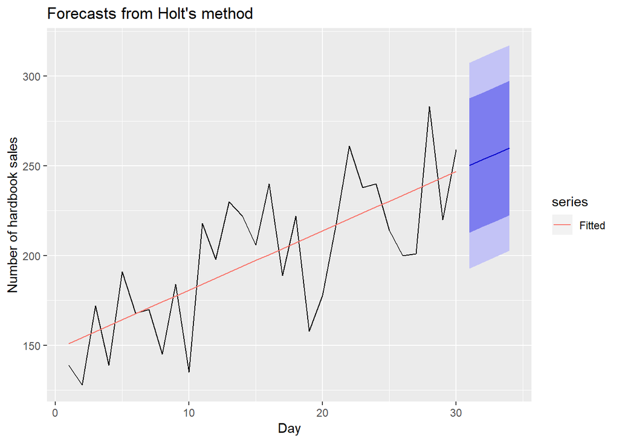

```r
autoplot(fc_hard_hl) +
  autolayer(fitted(fc_hard_hl), series="Fitted") +
  ylab("Number of hardbook sales") + xlab("Day")
```

```r
accuracy(fc_paper_hl)
```

```
##                     ME     RMSE      MAE       MPE     MAPE      MASE
## Training set -3.717178 31.13692 26.18083 -5.508526 15.58354 0.6602122
##                    ACF1
## Training set -0.1750792
```

```r
accuracy(fc_hard_hl)
```

```
##                      ME     RMSE      MAE       MPE    MAPE      MASE
## Training set -0.1357882 27.19358 23.15557 -2.114792 12.1626 0.6908555
##                     ACF1
## Training set -0.03245186
```

# b. Compare the RMSE measures of Holt’s method for the two series to those of simple exponential smoothing in the previous question. (Remember that Holt’s method is using one more parameter than SES.) Discuss the merits of the two forecasting methods for these data sets.

RMSEs for Holt’s are lower than SES’s. Since we know data is not white noise, Holt’s is suitable for these datasets. Holt’s is the extended version of SES to allow the forecasting of data with a trend. SES is suitable for data without a trend or seasonality.

```r
# Let's compare RMSE on training set between Hort Linear and SES

# Hort's
print(accuracy(fc_paper_hl))
```

```
##                     ME     RMSE      MAE       MPE     MAPE      MASE
## Training set -3.717178 31.13692 26.18083 -5.508526 15.58354 0.6602122
##                    ACF1
## Training set -0.1750792
```

```r
print(accuracy(fc_hard_hl))
```

```
##                      ME     RMSE      MAE       MPE    MAPE      MASE
## Training set -0.1357882 27.19358 23.15557 -2.114792 12.1626 0.6908555
##                     ACF1
## Training set -0.03245186
```

```r
# SES
print(accuracy(fc_paper))
```

```
##                    ME     RMSE     MAE       MPE     MAPE      MASE
## Training set 7.175981 33.63769 27.8431 0.4736071 15.57784 0.7021303
##                    ACF1
## Training set -0.2117522
```

```r
print(accuracy(fc_hard))
```

```
##                    ME     RMSE      MAE      MPE     MAPE      MASE
## Training set 9.166735 31.93101 26.77319 2.636189 13.39487 0.7987887
##                    ACF1
## Training set -0.1417763
```

# c. Compare the forecasts for the two series using both methods. Which do you think is best?

One might think that Holt’s method is better than SES since it does provide trend. I would choose Holt’s for these datasets as they are not stationary.

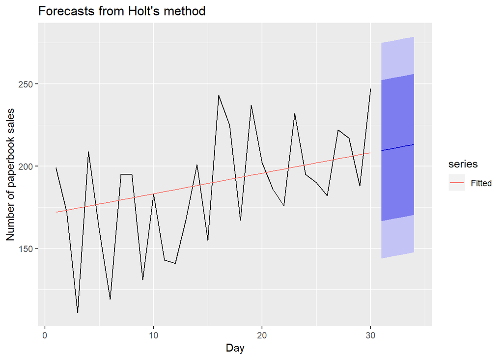

```r
autoplot(fc_paper_hl) +
  autolayer(fitted(fc_paper_hl), series="Fitted") +
  ylab("Number of paperbook sales") + xlab("Day")
```

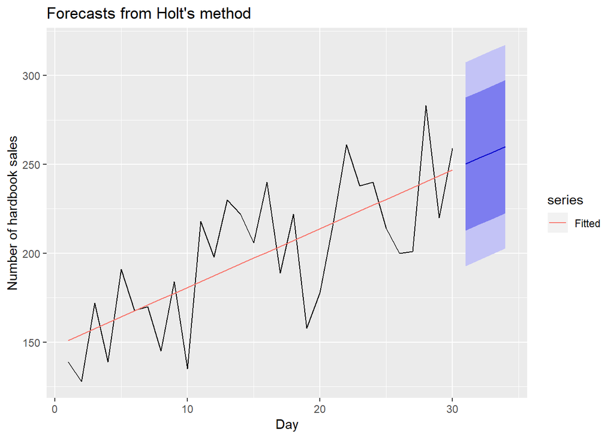

```r
autoplot(fc_hard_hl) +
  autolayer(fitted(fc_hard_hl), series="Fitted") +
  ylab("Number of hardbook sales") + xlab("Day")
```

# d. Calculate a 95% prediction interval for the first forecast for each series, using the RMSE values and assuming normal errors. Compare your intervals with those produced using ses and holt.

As expected, PIs are all different. Since SES is flat forecast and has higher RMSE, it does have wider PI than Holt’s.

```r
# Hort's
print(forecast(fc_paper_hl))[1,]
```

```
##    Point Forecast    Lo 80    Hi 80    Lo 95    Hi 95
## 31       209.4668 166.6035 252.3301 143.9130 275.0205
## 32       210.7177 167.8544 253.5811 145.1640 276.2715
## 33       211.9687 169.1054 254.8320 146.4149 277.5225
## 34       213.2197 170.3564 256.0830 147.6659 278.7735
```

```
##    Point Forecast    Lo 80    Hi 80   Lo 95    Hi 95
## 31       209.4668 166.6035 252.3301 143.913 275.0205
```

```r
holt(books[, 'Paperback'], h=1)$mean[1] - (1.96 * accuracy(fc_paper_hl)[2])
```

```
## [1] 148.4384
```

```r
holt(books[, 'Paperback'], h=1)$mean[1] + (1.96 * accuracy(fc_paper_hl)[2])
```

```
## [1] 270.4951
```

```r
print(forecast(fc_hard_hl))[1,]
```

```
##    Point Forecast    Lo 80    Hi 80    Lo 95    Hi 95
## 31       250.1739 212.7390 287.6087 192.9222 307.4256
## 32       253.4765 216.0416 290.9113 196.2248 310.7282
## 33       256.7791 219.3442 294.2140 199.5274 314.0308
## 34       260.0817 222.6468 297.5166 202.8300 317.3334
```

```
##    Point Forecast   Lo 80    Hi 80    Lo 95    Hi 95
## 31       250.1739 212.739 287.6087 192.9222 307.4256
```

```r
holt(books[, 'Hardcover'], h=1)$mean[1] - (1.96 * accuracy(fc_paper_hl)[2])
```

```
## [1] 189.1455
```

```r
holt(books[, 'Hardcover'], h=1)$mean[1] + (1.96 * accuracy(fc_paper_hl)[2])
```

```
## [1] 311.2022
```

```r
# SES
print(forecast(fc_paper))[1,]
```

```
##    Point Forecast    Lo 80    Hi 80    Lo 95    Hi 95
## 31       207.1097 162.4882 251.7311 138.8670 275.3523
## 32       207.1097 161.8589 252.3604 137.9046 276.3147
## 33       207.1097 161.2382 252.9811 136.9554 277.2639
## 34       207.1097 160.6259 253.5935 136.0188 278.2005
## 35       207.1097 160.0215 254.1979 135.0945 279.1249
```

```
##    Point Forecast    Lo 80    Hi 80   Lo 95    Hi 95
## 31       207.1097 162.4882 251.7311 138.867 275.3523
```

```r
ses(books[, 'Paperback'], h=1)$mean[1] - (1.96 * accuracy(fc_paper_hl)[2])
```

```
## [1] 146.0813
```

```r
ses(books[, 'Paperback'], h=1)$mean[1] + (1.96 * accuracy(fc_paper_hl)[2])
```

```
## [1] 268.138
```

```r
print(forecast(fc_hard))[1,]
```

```
##    Point Forecast    Lo 80    Hi 80    Lo 95    Hi 95
## 31       239.5601 197.2026 281.9176 174.7799 304.3403
## 32       239.5601 194.9788 284.1414 171.3788 307.7414
## 33       239.5601 192.8607 286.2595 168.1396 310.9806
## 34       239.5601 190.8347 288.2855 165.0410 314.0792
## 35       239.5601 188.8895 290.2306 162.0662 317.0540
```

```
##    Point Forecast    Lo 80    Hi 80    Lo 95    Hi 95
## 31       239.5601 197.2026 281.9176 174.7799 304.3403
```

```r
ses(books[, 'Hardcover'], h=1)$mean[1] - (1.96 * accuracy(fc_paper_hl)[2])
```

```
## [1] 178.5317
```

```r
ses(books[, 'Hardcover'], h=1)$mean[1] + (1.96 * accuracy(fc_paper_hl)[2])
```

```
## [1] 300.5885
```

# 10. For this exercise use data set `ukcars`, the quarterly UK passenger vehicle production data from 1977Q1-2005Q1.

# a.Plot the data and describe the main features of the series.

Strong seasonality every year (every 4 lags) from ACF, STL decomposition and Lag plot. We see an increasing trend in the data after 1980 (before, it was decreasing). From seasonal subseries plot, we know that Q.1s generally have the highest car production where as Q.3s are the lowest. The data is not white noise and stationary - every spike in every lag in ACF. Summary statistics shows that mean is almost the same as median, indicating that data is fairly normalized.

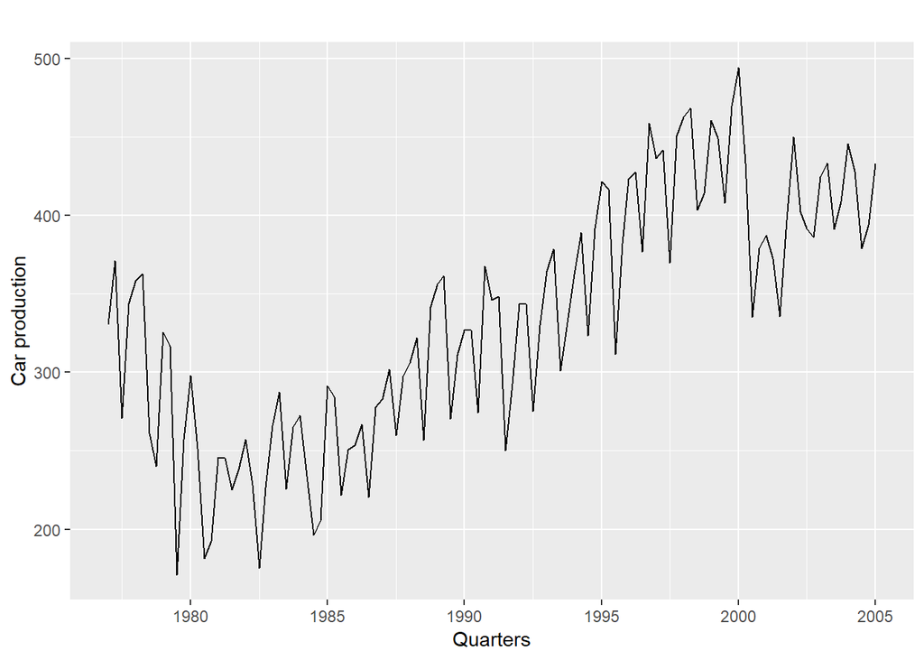

```r
# general plot
autoplot(ukcars) +
  ylab("Car production") + xlab("Quarters")
```

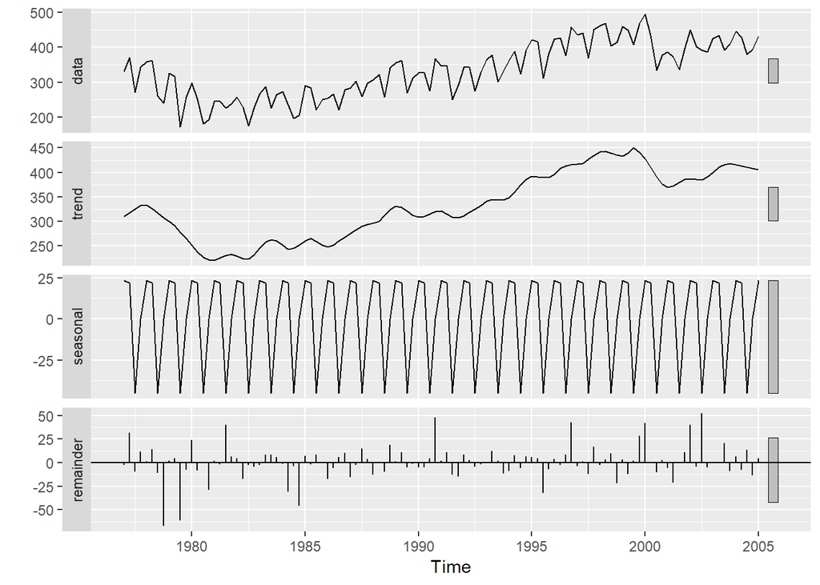

```r
# STL decomposition
ukcars %>%
  stl(s.window = 'periodic', robust = TRUE) %>%
  autoplot()
```

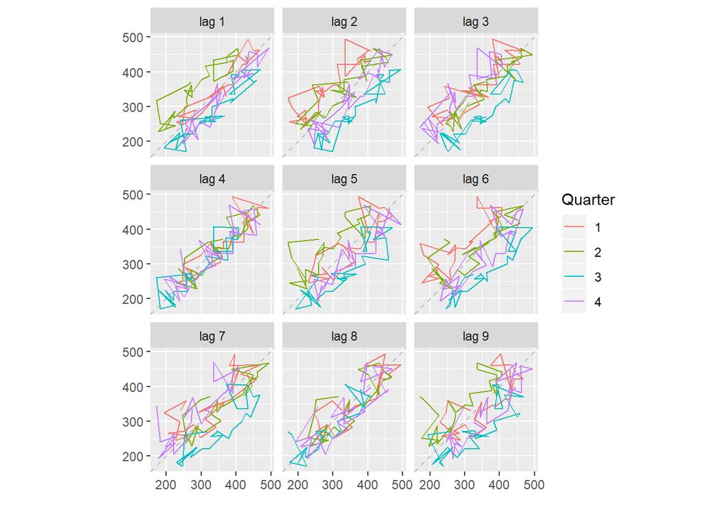

```r
# Lag plot
gglagplot(ukcars)
```

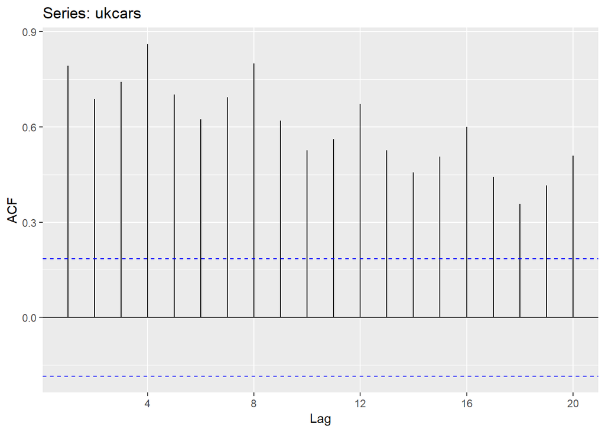

```r
# Autocorrelation
ggAcf(ukcars)
```

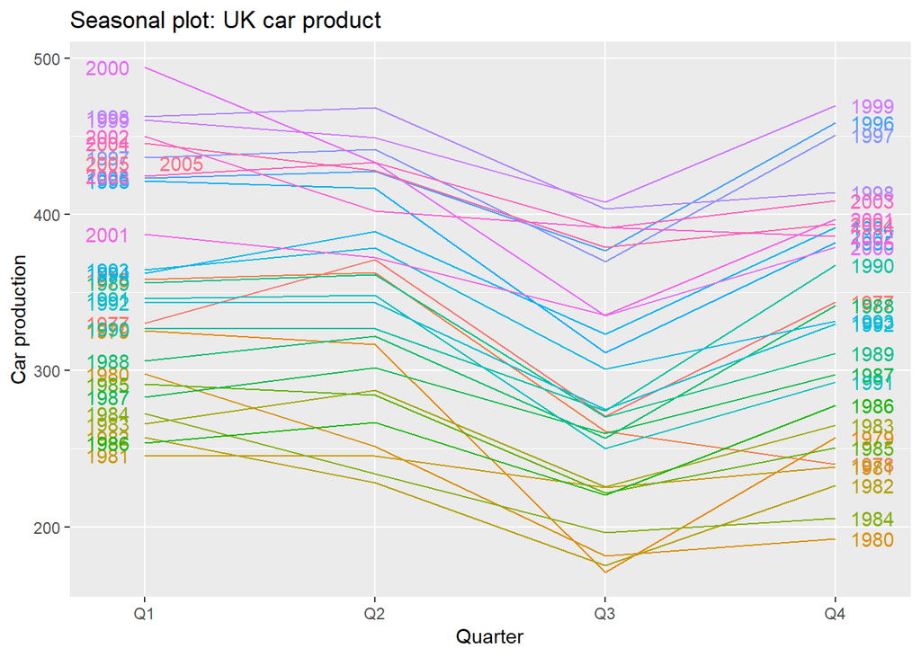

```r
# seasonal plot
ggseasonplot(ukcars, year.labels=TRUE, year.labels.left=TRUE) +
  ylab("Car production") +
  ggtitle("Seasonal plot: UK car product")
```

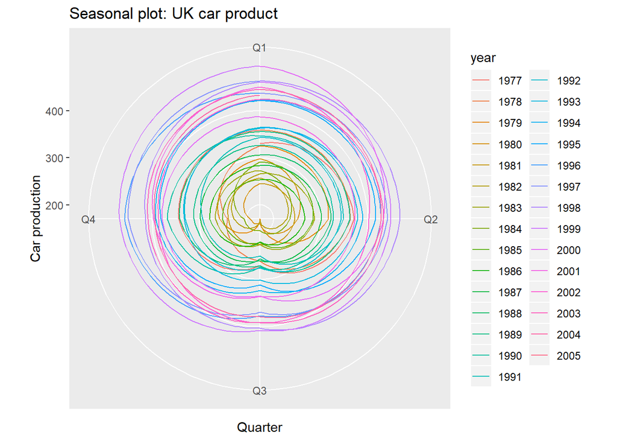

```r
ggseasonplot(ukcars, polar=TRUE) +
  ylab("Car production") +
  ggtitle("Seasonal plot: UK car product")
```

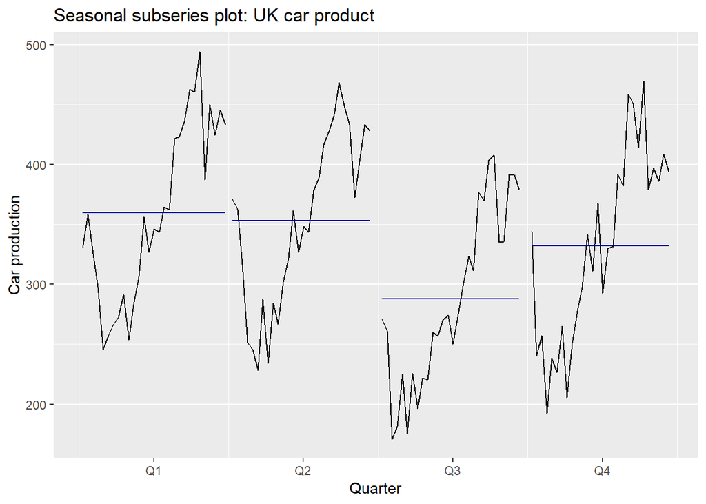

```r
# seasonal subseries plot
ggsubseriesplot(ukcars) +
  ylab("Car production") +
  ggtitle("Seasonal subseries plot: UK car product")
```

```r
# summary statistics
summary(ukcars)
```

```
##    Min. 1st Qu.  Median    Mean 3rd Qu.    Max.
##   171.2   267.0   335.1   333.5   391.8   494.3
```